# R_Lang_Exer

C.U. Yao

2018年7月8日

# 學習摘要

- 這裡是我學習R語言與RMarkdown的學習摘要，日期的標註是指章節建立的日期，日後都會有可能對前內容做出修改。

## 2018/7/4 (三)

### 在RMarkdown 中輸入R語言

- RMarkdown 作為R語言與Markdown的結合，可以在其中各自展現，除了Markdown本身的語法外，當我們想要輸入R語言時，應使用Markdown的程式碼區塊，並標記為R，這樣編譯器在執行時就會自動去編譯有R的部分。
  - 例如：
  - `` ```{r} ``
  - `R程式碼區塊`
  - `` ``` ``

> “Ctrl + Alt + I” 可以快速在編輯區中插入R語言片段
- 另需注意的是，雖然程式碼就像被“框”起來一般，但實際上並不是每個區段都獨立，而是都是共通的。在上一個區段宣告過的變數並不需要重新再宣告一次。有關RMarkdown的部分，之後會再繼續學習與探討。

### 基本運算子

- 以下是R語言的基本運算子，另外、我們可以直接在程式碼或是Console中輸入運算式，來得到運算結果。
- 加法

```r
1+1
```

```
## [1] 2
```

- 減法

```r
2-1
```

```
## [1] 1
```

- 乘法

```r
2*2
```

```
## [1] 4
```

- 除法

```r
4/2
```

```
## [1] 2
```

- 乘幕

```r
2^16
```

```
## [1] 65536
```

- 餘數

```r
5 %% 3
```

```
## [1] 2
```

## 2018/7/7 (六)

## 變數的宣告

- 在R中，變數的宣告相當的簡潔。

```r
#變數的宣告
Hamburger <- 32
#Print out
Hamburger
```

```
## [1] 32
```

```r
#Print out of calculate variable
Hamburger * 2
```

```
## [1] 64
```

## 基本資料類別

- R 有眾多資料類別，以下是較為基本的：
  - 數值(Numeric)：49.32
  - 整數(Integer)：49
  - 邏輯值(Logical)：TRUE，FALSE
  - 文字(Characters)：“banana”
- 其中特別的是數值是指有小數的數。
- 在宣告變數時，變數的資料類別會直接從其宣告的形式或資料的內容來確立。
- 要注意R語言是會區分字母大小的。

```r
# Create Numeric
my_pi <- 3.1415926
# Create Integer
my_fafafafa <- 8888
# Create Logical
my_logical <- TRUE
# Create Characters
my_name <- "Yao"
# 只要使用雙引號，就會直接被歸類成字串
```

- 另外，我們可以使用 `class()` 這個函數來檢視資料類別。

```r
class(my_pi)
```

```
## [1] "numeric"
```

```r
class(my_fafafafa)
```

```
## [1] "numeric"
```

```r
class(my_logical)
```

```
## [1] "logical"
```

```r
class(my_name)
```

```
## [1] "character"
```

## 向量

- 使用 `c()` 來建立向量

```r
abc <- c("apple","banana","caves")
abc
```

```
## [1] "apple"  "banana" "caves"
```

- 元素的命名
  - 可使用 `names()` 來對元素命名

```r
names(abc) <- c("A","B","C")
abc
```

```
##        A        B        C
##  "apple" "banana"  "caves"
```

- 向量可透過以下方式進行計算

```r
X_vector <- c(1, 2, 3)
Y_vector <- c(4, 5, 6)

total_vector <- X_vector + Y_vector

total_vector
```

```
## [1] 5 7 9
```

- 可使用 `sum()` 來加總向量中所有的元素

```r
total_vector
```

```
## [1] 5 7 9
```

```r
sumtotal <- sum(total_vector)
```

- 若選擇向量中的元素，應使用 `[]` 來選擇。要注意的是，R語言的第一個元素的索引值是 1，不像其他程式語言第一個元素的索引值是 0。

```r
select_total <- total_vector[1]
select_total
```

```
## [1] 5
```

- 多重選擇時應使用 `c()` 函數。

```r
select_total <- total_vector[c(1,2)]
select_total
```

```
## [1] 5 7
```

- 除了使用索引值來選擇外，也可使用元素的名稱來選擇。

```r
names(total_vector) <- c("pizza","cake","coffee")
select_total2 <- total_vector["pizza"]
select_total2
```

```
## pizza
##     5
```

```r
# muli
select_total2 <- total_vector[c("pizza","coffee")]
select_total2
```

```
##  pizza coffee
##      5      9
```

- 可直接使用比較運算子來判斷真假

```r
sumtotal
```

```
## [1] 21
```

```r
sumtotal > 30
```

```
## [1] FALSE
```

```r
# sumtotal 的值為21 由此可知並不大於30
```

- 向量中元素的比較

```r
total_vector
```

```
##  pizza   cake coffee
##      5      7      9
```

```r
total_vector > 4
```

```
##  pizza   cake coffee
##   TRUE   TRUE   TRUE
```

- 以下為R的比較運算子
  - “<” 小於(for less than)
  - “>” 大於(for greater than)
  - “<=” 小於或等於(for less than or equal to)
  - “>=” 大於或等於(for greater than or equal to)
  - “==” 等於(for equal to each other)
  - “!=” 不等於(not equal to each other)
- 我們可以使用比較的結果來進行選擇，R會自動選擇“TRUE”的結果。

```r
total_vector
```

```
##  pizza   cake coffee
##      5      7      9
```

```r
com_8_res <- total_vector[total_vector < 8]
com_8_res
```

```
## pizza  cake
##     5     7
```

```r
#可以看到只有小於8的5和7被選擇，9因為比8大，所以並沒有被選擇進來。
```

# 2018/7/8 (日)

## 矩陣

- 使用 `matrix(elements,byrow,nrow)` 來建立矩陣。

```r
matrix(1:9,byrow = TRUE, nrow = 3)
```

```
##      [,1] [,2] [,3]
## [1,]    1    2    3
## [2,]    4    5    6
## [3,]    7    8    9
```

- 其中的參數解釋如下：
  - 1:9 -> 陣列的元素，此處指 `c(1,2,3,4,5,6,7,8,9)`。
  - byrow = TRUE -> 擺放方式，TRUE為列、FALSE為欄
  - nrow = 3 -> 以三列方式進行排序，其中 `nrow = 3` 可直接被省略成 `3`。
- 如同向量、矩陣中的元素也可以被命名(這個說法其實不大正確)，但是概念不大一樣。在向量中，他是單一維度的陣列，所以與其說是為元素命名，不如說所作的事情就像是在為欄位命名一樣(因為只有一列)；而矩陣是個二維陣列，所以我們可以做的事情是對列與欄進行命名。 *我們可以使用 `rownames(my_matrix)` 及 `colnames(my_matrix)` 來對矩陣的列與欄命名。

```r
# Box office Harry Potter (in millions)
Philosopher_Stone <- c(317,657)
Chamber_of_Secrets <- c(261,616)
Prisoner_of_Azkaban <- c(249,547)
# Matrix Create
Harry_Potter <- matrix(c(Philosopher_Stone,Chamber_of_Secrets,Prisoner_of_Azkaban),byrow = TRUE, nrow = 3)
# name it
region <- c("US", "non-US")
titles <- c("Philosopher Stone", "Chamber of Secrets", "Prisoner of Azkaban")
# 用 region 為欄命名
colnames(Harry_Potter)<-region

# 用 titles 為列命名
rownames(Harry_Potter)<-titles
# Show it
Harry_Potter
```

```
##                      US non-US
## Philosopher Stone   317    657
## Chamber of Secrets  261    616
## Prisoner of Azkaban 249    547
```

- 我們可以利用 `rowSums(my_matrix)` 來計算矩陣中每一列的總和；使用 `colSums(my_matrix)` 來計算每一欄的總和。

```r
rowSums(Harry_Potter)
```

```
##   Philosopher Stone  Chamber of Secrets Prisoner of Azkaban
##                 974                 877                 796
```

```r
colSums(Harry_Potter)
```

```
##     US non-US
##    827   1820
```

- 我們可以利用 `cbind(matrix1,matrix2)` 來結合矩陣欄

```r
cbind(Harry_Potter,rowSums(Harry_Potter))
```

```
##                      US non-US
## Philosopher Stone   317    657 974
## Chamber of Secrets  261    616 877
## Prisoner of Azkaban 249    547 796
```

```r
#　直接加入的話並不會有欄位的名稱，但如果先行定義變數，就會自動將變數的值帶入。
# Ex 1
Play_times <- c(12,23,34)
cbind(Harry_Potter,Play_times)
```

```
##                      US non-US Play_times
## Philosopher Stone   317    657         12
## Chamber of Secrets  261    616         23
## Prisoner of Azkaban 249    547         34
```

```r
# Ex 2
Harry_Potter_total <- rowSums(Harry_Potter)
cbind(Harry_Potter,Harry_Potter_total)
```

```
##                      US non-US Harry_Potter_total
## Philosopher Stone   317    657                974
## Chamber of Secrets  261    616                877
## Prisoner of Azkaban 249    547                796
```

- 結合矩陣列的話，就要使用 `rbind(matrix1,matrix2)` 。

```r
# other movies of harrypotter
Goblet_of_Fire <- c(290,896)
Order_of_the_Phoenix <- c(292,647)
Half_Blood_Prince <- c(301,632)
Deathly_Hallows1 <- c(295,664)
Deathly_Hallows2 <- c(381,960)
Harry_Potter2 <-
matrix(
  c(
    Goblet_of_Fire,Order_of_the_Phoenix,Half_Blood_Prince,Deathly_Hallows1,Deathly_Hallows2
   ),
  nrow = 5, byrow = TRUE,
  dimnames = list #可以直接使用dimnames 來命名、清單的用法之後會說。
    (
      c("Goblet of Fire", "Order of the Phoenix", "Half-Blood Prince",
       "Deathly Hallows 1","Deathly Hallows 2"),
      c("US", "non-US")
    )
  )
# combine it
Harry_Potter_All <- rbind(Harry_Potter,Harry_Potter2)
Harry_Potter_All
```

```
##                       US non-US
## Philosopher Stone    317    657
## Chamber of Secrets   261    616
## Prisoner of Azkaban  249    547
## Goblet of Fire       290    896
## Order of the Phoenix 292    647
## Half-Blood Prince    301    632
## Deathly Hallows 1    295    664
## Deathly Hallows 2    381    960
```

- 若要選取矩陣中的元素，應使用 `my_matrix[row,columns]` 。
- 由於矩陣是一個二維陣列，所以需要分別指定列與欄的相對位置。

```r
# 選取第一列第二行
Harry_Potter_All[1,2]
```

```
## [1] 657
```

```r
# 選取第一至第四列的第二行
Harry_Potter_All[1:4,2]
```

```
##   Philosopher Stone  Chamber of Secrets Prisoner of Azkaban
##                 657                 616                 547
##      Goblet of Fire
##                 896
```

```r
# 選取全部的第二行
Harry_Potter_All[,2]
```

```
##    Philosopher Stone   Chamber of Secrets  Prisoner of Azkaban
##                  657                  616                  547
##       Goblet of Fire Order of the Phoenix    Half-Blood Prince
##                  896                  647                  632
##    Deathly Hallows 1    Deathly Hallows 2
##                  664                  960
```

```r
# 有關欄的選取，同理反證。
```

- 另外 我們可以使用 `mean()` 函數來計算平均值。

```r
# 哈利波特八部電影的美國外平均票房
mean(Harry_Potter_All[,2])
```

```
## [1] 702.375
```

- 可以直接將矩陣進行數學運算，矩陣中的所有元素會一同被獨立運算。

```r
Harry_Potter_All / 2
```

```
##                         US non-US
## Philosopher Stone    158.5  328.5
## Chamber of Secrets   130.5  308.0
## Prisoner of Azkaban  124.5  273.5
## Goblet of Fire       145.0  448.0
## Order of the Phoenix 146.0  323.5
## Half-Blood Prince    150.5  316.0
## Deathly Hallows 1    147.5  332.0
## Deathly Hallows 2    190.5  480.0
```

```r
#矩陣的互算
Apple_P <- matrix(c(20,30,40),byrow=TRUE,3)
Apple_Q <- matrix(c(60,50,20),byrow=TRUE,3)
Apple_R <- Apple_P * Apple_Q
Apple_R
```

```
##      [,1]
## [1,] 1200
## [2,] 1500
## [3,]  800
```

## 因素向量

```r
sex <- c("F", "F", "F", "M", "M")
factor_sex <- factor(sex) # 對sex向量設定為因素向量(類別型變數)
levels(factor_sex) <- c("Female","Male")
factor_sex
```

```
## [1] Female Female Female Male   Male
## Levels: Female Male
```

- `summary(my_data)` 可展示資料的摘要(向量、因素向量等…)

```r
summary(sex)
```

```
##    Length     Class      Mode
##         5 character character
```

```r
summary(factor_sex)
```

```
## Female   Male
##      3      2
```

- 非比較級(名目類別)的因素向量是沒有辦法被比較的。。

```r
factor_sex[1] > factor_sex[2]
```

```
## [1] NA
```

*若要建立比較級(順序類別)，則需在建立因素向量時多輸入幾個參數與設定。

```r
speed_f<- factor(c("fast","fast","slow","slow","insane","fast"),
       ordered = TRUE, # 設定為順序類別
       levels = c("slow","fast","insane") # 設定正確的比較級數 (由小到大)
       )
speed_f
```

```
## [1] fast   fast   slow   slow   insane fast
## Levels: slow < fast < insane
```

```r
summary(speed_f)
```

```
##   slow   fast insane
##      2      3      1
```

- 比較級(順序類別)的因素向量就可以被比較了。

```r
speed_f[1] > speed_f[3]
```

```
## [1] TRUE
```

```r
speed_f[1] > speed_f[5]
```

```
## [1] FALSE
```

- 對此章節作個簡單的整理
  - 變數有分類別型變數與連續型變數。
  - 類別型變數中有分順序類別與名目類別。
  - 向量作為變數的一種，一般的向量為連續型變數，因素向量則為類別型變數。
  - 因素向量的順序類別與名目類別又稱為順序型因素向量與名目型因素向量。
- 由於用文字解釋實在是太複雜了，所以用樹狀圖呈現比較好吧：
- 中文版

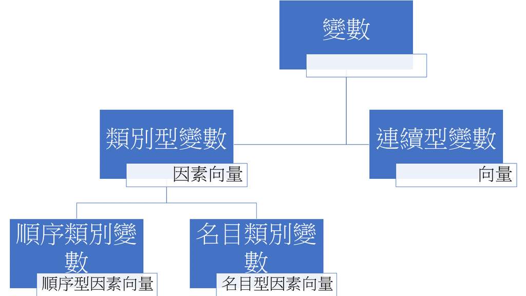

- 英文版

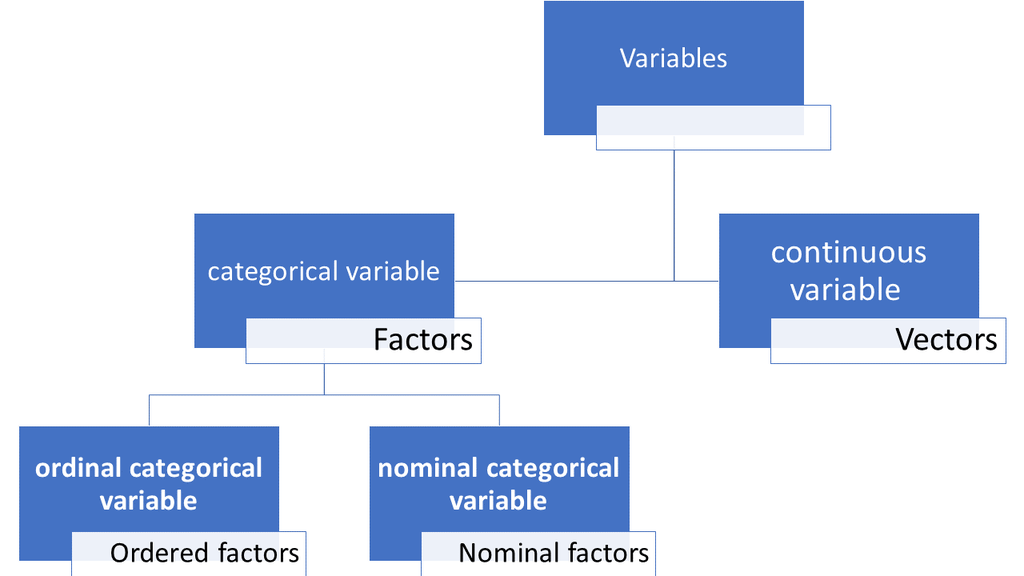

- 上兩張圖的PPT。

# 參考來源

- 以上內容有參考以下來源之部分論述與程式碼
  - CornelissenJonathan. (2018年7月8日). Introduction to R. 擷取自 DataCamp: https://www.datacamp.com/courses/free-introduction-to-r
  - KuoYao-Jen. (2016年7月16日). R 語言導論. 擷取自 DataCamp: https://www.datacamp.com/community/open-courses/r-語言導論
- Harry Potter 票房資料
  - IMDb.com, Inc. (2018年7月8日). Total Lifetime Grosses. 擷取自 Box Office Mojo: http://www.boxofficemojo.com/